# Raster resampling in R

Cesar Aybar

2018-12-05

## 1. Intro

A typical workflow for earth analysts always will have to do with several spatial data sources (e.g. Sentinel, MODIS and Landsat) each one with a particular extent and pixel resolution. **Resampling** is the technique used to *homogenize* these spatial attributes.

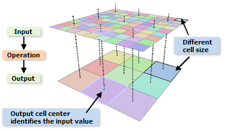

Image obtained from [here](http://desktop.arcgis.com/en/arcmap/latest/extensions/spatial-analyst/performing-analysis/cell-size-and-resampling-in-analysis.htm)

This post demonstrate how easy and incredibly fast is resampling gridded data in R using the [raster](https://cran.r-project.org/web/packages/raster/index.html) and [gdalUtils](https://cran.r-project.org/web/packages/gdalUtils/index.html) packages. If you do not familiarize with they , first, look at this [tutorial](https://geoscripting-wur.github.io/IntroToRaster/) or run in R:

```r
vignette("functions", package = "raster") # Run me in R!
```

While `raster` package allow to perform fast operation thanks to optimized back-end C code, some raster manipulation techniques such as `raster::resample()` can become incredibly slow as the raster size increase. A effective alternative but a little more complicated to code is use a **wrapper library** (gdalUtils).

## 2. Wrapper libraries

In few words, a *wrapper* library (not confuse with a binding library) is a piece of code which translate a library’s existing (e.g GDAL) into a different interface (e.g an R package). The main advantage is that you will use GDAL in its original language (C++). Check it [this](https://stackoverflow.com/questions/8628326/what-is-the-difference-between-a-wrapper-bindings-and-a-port) for a more comprehensible explanation.

## 3. Demo

**Before coding do not forget install and load the packages!**

```r
library('raster')
library('ggplot2')
library('gdalUtils')
library('rasterVis')
library('sf')
library('kableExtra')
library('mapview')
library('future')
library('purrr') # ex girlfriend
library('furrr') # new girlfriend
library('tidyverse')
```

### 3.1 Downloading PISCOpclim

```r
user <- 'publi_dgh2' # ftp user
pass <- '123456'   # ftp user
ftp <- 'ftp.senamhi.gob.pe/PISCOp_V2.1_beta/' # url
dir <- 'PISCOp_climatology/PISCOp_climatology/' # urn
months <- sprintf('%02d',1:12) # GEOtiff names
clim <- sprintf('ftp://%s:%s@%s%s%s.tif', user, pass, ftp, dir,months)

ftp_n <- mapply(download.file, clim,basename(clim),quiet = TRUE)
```

### 3.3 Arequipa Region

```r
# Creating a polygon of the PISCOp extent
piscop_extent <- clim_stack[[1]] %>%
                  extent %>%
                  raster(nrows=1,ncols=1) %>%
                  as('SpatialPolygons') %>%
                  st_as_sf()

piscop_extent$NOMBRE = 'PISCOp extent'

arequipa <- st_read('arequipa_simply.shp', quiet = TRUE)
m_01 <- mapview(arequipa)
m_02 <- mapview(piscop_extent, fill=NA)

m_01 + m_02
```

### 3.4 Method 01: Resampling via `raster` package

```r
raster_base <- crop(clim_stack[[1]], arequipa)
res(raster_base) <- 0.05

system.time(
clim_1_a <- resample(clim_stack,raster_base,method='bilinear')
)

plot(clim_1_a[[1]], main = 'Jan Precipitation in Arequipa')
plot(as(arequipa,'Spatial'),add=T)
```

[output not shown]

### 3.5 Method 02: Resampling via `gdalUtils` package

```r
#' Resampling a Raster* object via GDAL
#'
#' @param r Raster* object to be resampled
#' @param r_base Raster* object with parameters that r
#' should be resampled to.
#' @param method Character. GDAL resampling_method
#' ("near"|"bilinear"|"cubic"|"cubicspline"|
#'  "lanczos"|"average"|"mode"|"max"|"min"|
#'  "med"|"q1"|"q3")
#'
#' @export
gdal_resample <- function(r,r_base,method='bilinear') {

  #Geometry attributes
  t1 <- c(xmin(r_base), ymin(r_base),
          xmax(r_base), ymax(r_base))
  res <- res(r_base)

  #Temporal files
  tmp_outname <- sprintf('%s.tif',tempfile())
  tmp_inname <- sprintf('%s.tif',tempfile())
  writeRaster(r,tmp_inname)

  #GDAL time!
  gdalwarp(tmp_inname,tmp_outname,tr=res,te=t1,r = method)
  resample_raster = raster(tmp_outname)
  mapply(file.remove,c(tmp_inname,tmp_outname))
  return(resample_raster)
}
```

**Sequential approach**

```r
system.time(
clim_1_b <- names(clim_stack) %>%
  map(~ gdal_resample(clim_stack[[.x]],raster_base)) %>%
  stack()
)

plot(clim_1_a[[1]], main = 'Jan Precipitation in Arequipa')
plot(as(arequipa,'Spatial'),add=T)
```

[output not shown]

**Multiprocess approach**

```r
message(sprintf('%s \n',system('lscpu',intern = T)))
```

```r
plan(multiprocess)
```

```r
system.time(
clim_1_b <- names(clim_stack) %>%
  future_map(~ gdal_resample(clim_stack[[.x]],raster_base)) %>%
  stack()
)
plot(clim_1_a[[1]], main = 'Jan Precipitation in Arequipa')
plot(as(arequipa,'Spatial'),add=T)
```

[output not shown]

## raster vs gdalUtils Comparison (Simple Benckmark)

```r
cell_size <- c(0.05,0.025,0.01,0.005,0.0025,0.001)


for(x in cell_size) {

  raster_base <- crop(clim_stack[[1]], arequipa)
  res(raster_base) <- x

  time_m01 <- system.time(
    clim_1_a <- resample(clim_stack[[1:4]],
                         raster_base,
                         method='bilinear'))

  time_m02 <- system.time(
    clim_1_b <- names(clim_stack)[1:4] %>%
      map(~ gdal_resample(clim_stack[[.x]],raster_base)) %>%
      stack())

  time_m03 <- system.time(
    clim_1_c <- names(clim_stack)[1:4] %>%
      future_map(~ gdal_resample(clim_stack[[.x]],
                                 raster_base)) %>%
      stack())

  df_size <- data_frame(
    pixel_size = x,
    npixels = ncell(clim_1_a)*12,
    raster = time_m01[3],
    gdalUtils = time_m02[3],
    gdalUtils_4par = time_m03[3]
  )
  if (x == 0.05) {
    df_base <- df_size
  } else {
    df_base <- bind_rows(df_base, df_size)
  }
}
```

```r
kable(df_base)
df_base %>%
  gather(package,time,-npixels,-pixel_size) %>%
  ggplot(aes(x=npixels,y=time,color=package))+
  geom_line()+
  geom_point()
```

[output not shown]